# Correction TD4

Pierre-O Goffard

17 janvier 2019

## TD 4

### Exercice 1

#### 1)

Regarder la fonction `unique()` et écrire une fonction `unique_mine()` qui reproduit la fonction `unique()`. Mettre le code R

```r
#' unique_myown prend en argument un vecteur et renvoit un vecteur sans les doublons du vecteur initial
#'
#' @param x : un vecteur
#'
#' @return un vecteur ne contenant que des éléments distinct
#' @export
#'
#' @examples
unique_myown <- function(x){
  x_unique <- vector()
  for(k in 1:length(x)){
    if(x[k] %in% x_unique){
      x_unique[k] <- NA
    }else{
      x_unique[k] <- x[k]
    }
  }
  return(x_unique[!is.na(x_unique)])
}

#Test de la fonction
x = c(1,2,1,45,2,3)
unique(x) == unique_myown(x)
```

```
## [1] TRUE TRUE TRUE TRUE
```

#### 2)

Ecrire une fonction `rev_myown` qui reproduit la fonction rev. Mettre le code R.

```r
#' rev_myown reproduit la fonction rev
#'
#' @param x : un vecteur
#'
#' @return un vecteur dont l'ordre est exactement l'inverse du vecteur x
#' @export
#'
#' @examples
rev_myown <- function(x){
  x[sort(1:length(x), decreasing = T)]
}

x <- c(14, 47, 104, 89)
rev_myown(x)
```

```
## [1]  89 104  47  14
```

```r
rev(x)
```

```
## [1]  89 104  47  14
```

### Exercice 2

#### 1)

Ecrire une fonction `variance` prenant en argument un vecteur `x ($x = (x_1, \ldots, x_n)$)` et un booléen `biased` qui retourne l’estimateur biasé
$$\tilde{S}_n^2 = \frac{1}{n}\sum_{k=1}^{n}(x_k - \bar{x})^{2}$$
de la variance, où $\bar{x}=\frac{1}{n}\sum_{k=1}^{n}x_k$ désigne la moyenne empirique, lorsque `biased = TRUE` et l’estimateur non-biasé
$$\widehat{S}_{n}^2 = \frac{1}{n-1}\sum_{k=1}^{n}(x_k - \bar{x})^{2}$$
de la variance lorsque `biased = FALSE`. On n’utilisera pas la fonction `var`. Mettre le code R.

```r
#' variance calcule la variance empirique d'une suite d'observations
#'
#' @param x vecteur numérique
#' @param biased booléen indiquant si l'estimateur biasé ou sans biais est évalué
#'
#' @return la variance empirique
#' @export
#'
#' @examples
variance <- function(x, biased){
  if(biased){
    est <- mean((x - mean(x))^{2})
  }else{
    est <- sum((x - mean(x))^{2}) / (length(x) - 1)
  }
  return(est)
}

# Variance empirique sans biais d'un échantillon de taille 2000 de réalisations d'une variable aléatoire de loi normale centrée réduite
variance(rnorm(2000), F)
```

```
## [1] 0.9652298
```

### 2)

```r
#' harmonique_mean calcule la moyenne harmonique d'une série d'observation
#'
#' @param x vecteur numérique
#'
#' @return la moyenne harmonique
#' @export
#'
#' @examples
harmonique_mean <- function(x){
  length(x) / mean(1 / x)
}

# Moyenne harmonique d'un échantillon de taille 1000 de réalisations d'une variable aléatoire de loi exponentielle de paramètre 1.
harmonique_mean(rexp(1000, rate = 1))
```

```
## [1] 134.7111
```

## Exercice 3

La valeur actuelle d’une série de paiement ($\text{Pmt} = (P_1,\ldots, P_n)$) effectué chaque fin de période est donnée par
$$\text{VA}(\text{Pmt}, \text{Tx}) = \sum_{k=1}^{n}\prod_{l=1}^{k}(1+i_l)^{-1}P_k$$
où $\text{Tx} = (i_1,\ldots, i_n)$ représente les taux d’intérêt applicable chaque période. Ecrire une fonction qui prend en argument un vecteur de paiment `Pmt` et un vecteur de taux d’intérêt et qui renvoit la valeur actuelle de la série de paiements. Mettre le code R. Pas de boucle `for`.

```r
#' Calcule_VA calcule la valeur actuelle de la somme d'une série de paiement
#'
#' @param Pmt vecteur numérique de paiment
#' @param Tx vecteur numérique de taux d'intérêt
#'
#' @return
#' @export
#'
#' @examples
Calcule_VA <- function(Pmt, Tx){
  cumprod(1 / (1 + Tx)) %*% Pmt
}

Tx = rep(0.05, 5)
Pmt = rep(100, 5)
# Calcul de la valeur actuelle d'une série de versement de montant 100 au taux d'actualisation fixe de 5%
Calcule_VA(Pmt, Tx)
```

```
##          [,1]
## [1,] 432.9477
```

## Exercice 4

### 1)

Deux dés à trois faces sont utilisés pour simuler le mouvement des indices boursiers. - Le premier dé donne la direction du mouvement `baisse, hausse, nul` - Le deuxième dé donne l’amplitude du mouvement à la hausse ou à la baisse le cas échéant. Les valeurs possibles sont `5, 10, 20`.

Ecrire une fonction `simule_indice` qui prend en argument la valeur initiale de l’indice boursier `x0` et l’horizon de projection `horizon` et qui renvoit un data frame contenant `horizon` lignes et $4$ variables

- `periode` la période en cours
- `Direction` le mouvement de l’indice sur la période en cours
- `Amplitude` l’amplitude du mouvement sur la période en cours (égale à $0$ en case de mouvement nul `Direction==nul`)
- `Xt` la valeur de l’indice en fin de période.

```r
#' simule_indice
#'
#' @param horizon Nombre entier égale à l'horizon de projection
#' @param x0 Valeur initiale de l'indice boursier
#'
#' @return Un data frame contenant 4 variables dont l'indice de la période courante, la direction de l'iondice et l'amplitude de la variation au cours de la période et la valeur de l'indice en fin de période
#' @export
#'
#' @examples

simule_indice <- function(horizon, x0){
  # Directions possibles
  direction <- c("hausse", "baisse", "nul")
  # Amplitudes possibles
  amplitude <- c(5, 10, 20)
  # Simulation des dircetion jusqu'à la fin de la projection
  direction_vec <- sample(direction, horizon, replace = T)
  amplitude_vec <- rep(0, horizon)
  for(k in 1:horizon){
    if(direction_vec[k] == "nul"){

      amplitude_vec[k] <- 0

    }else if(direction_vec[k] == "baisse"){

      amplitude_vec[k] <- - sample(amplitude, 1)

    }else{

      amplitude_vec[k] <-  sample(amplitude, 1)

      }

  }
  data.frame(periode = 1:horizon,  direction = direction_vec, amplitude = amplitude_vec, indice = x0 + cumsum(amplitude_vec))
}

simule_indice(horizon = 10, x0 = 100)
```

```
##    periode direction amplitude indice
## 1        1       nul         0    100
## 2        2       nul         0    100
## 3        3       nul         0    100
## 4        4       nul         0    100
## 5        5    hausse        10    110
## 6        6    baisse       -20     90
## 7        7    baisse       -10     80
## 8        8    hausse        10     90
## 9        9    hausse        10    100
## 10      10    baisse        -5     95
```

### 2)

Utiliser la fonction pour générer une trajectoire de l’indice boursier sur 2000 périodes d’exercice, on prendra $100$ comme valeur initiale. Tracer le graphique de la valeur de l’indice en fonction du temps. Ne mettre que l’image.

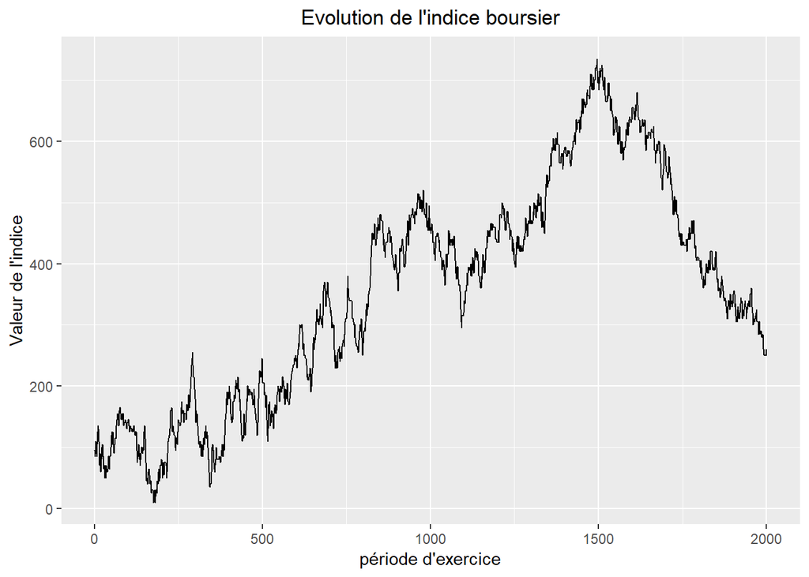

```r
library(ggplot2)
# Création du data frame
indice_2000 <- simule_indice(2000, 100)
#Construction du graphique
ggplot(data = indice_2000) + geom_line(mapping = aes(x = periode, y = indice)) + xlab("période d'exercice") + ylab("Valeur de l'indice") + ggtitle("Evolution de l'indice boursier")  + theme(plot.title = element_text(hjust = 0.5))
```